# CardioGoodFitness_Project

```python
#import sys
#!{sys.executable} -m pip install pandas-profiling
```

```python
#Libraries to help with reading data and manipulating data
import numpy as np
import pandas as pd
import matplotlib.pyplot as plt

# Libraries that support data visualization
import matplotlib.pyplot as plt
%matplotlib inline
import seaborn as sns

# Libraries to suppress warnings
import warnings
warnings.filterwarnings("ignore")
```

```python
#Load the dataset
```

```python
data = pd.read_csv("CardioGoodFitness.csv")
```

```python
#copying data to another data frame to avaoid changes in the original data
df = data.copy()
```

```python
df.head() # display 5 rows from the dataframe
```

|  | Product | Age | Gender | Education | MaritalStatus | Usage | Fitness | Income | Miles |
| --- | --- | --- | --- | --- | --- | --- | --- | --- | --- |
| 0 | TM195 | 18 | Male | 14 | Single | 3 | 4 | 29562 | 112 |
| 1 | TM195 | 19 | Male | 15 | Single | 2 | 3 | 31836 | 75 |
| 2 | TM195 | 19 | Female | 14 | Partnered | 4 | 3 | 30699 | 66 |
| 3 | TM195 | 19 | Male | 12 | Single | 3 | 3 | 32973 | 85 |
| 4 | TM195 | 20 | Male | 13 | Partnered | 4 | 2 | 35247 | 47 |

### Observations

1. Product, Gender and MaritalStatus are Categorical Variables
2. Age, Education, Usage, Income and Miles are Numerical Variables
3. Fitness is a categorical variable. Hence, it needs to be converted.

```python
df.shape
```

```
(180, 9)
```

### Observation

There are 180 rows and 9 columns

```python
df.info()
```

[output not shown]

### Observations

1. All columns have 180 observations indicating there are no misisng values
2. product, Gender and Marital Status are object datatype (should be categorical variables).

## Summary of dataset

```python
df.describe().T
```

|  | count | mean | std | min | 25% | 50% | 75% | max |
| --- | --- | --- | --- | --- | --- | --- | --- | --- |
| Age | 180.0 | 28.788889 | 6.943498 | 18.0 | 24.00 | 26.0 | 33.00 | 50.0 |
| Education | 180.0 | 15.572222 | 1.617055 | 12.0 | 14.00 | 16.0 | 16.00 | 21.0 |
| Usage | 180.0 | 3.455556 | 1.084797 | 2.0 | 3.00 | 3.0 | 4.00 | 7.0 |
| Income | 180.0 | 53719.577778 | 16506.684226 | 29562.0 | 44058.75 | 50596.5 | 58668.00 | 104581.0 |
| Miles | 180.0 | 103.194444 | 51.863605 | 21.0 | 66.00 | 94.0 | 114.75 | 360.0 |

### Observation

1. There is a huge difference between the 3rd quartile and the maximum value for the income and miles indicating there might be outliers to the right of these values
2. Age has a wide range indicating a range of age groups.

By default the describe() function shows only the summary of numeric variables only. Let's check the summary of non-numeric variables.

```python
df.describe(exclude='number').T
```

|  | count | unique | top | freq |
| --- | --- | --- | --- | --- |
| Product | 180 | 3 | TM195 | 80 |
| Gender | 180 | 2 | Male | 104 |
| MaritalStatus | 180 | 2 | Partnered | 107 |

### Observations

1. The variable 'Product' has 3 unique variations. The variables, 'Gender' and 'MaritalStatus' have 2 unique categories

Let's check the count of each unique category in each of the categorical variables.

```python
category = ['Product', 'Gender', 'MaritalStatus']

for column in category:
    print(df[column].value_counts())
    print('_'*40)
```

```
TM195    80
TM498    60
TM798    40
Name: Product, dtype: int64
________________________________________
Male      104
Female     76
Name: Gender, dtype: int64
________________________________________
Partnered    107
Single        73
Name: MaritalStatus, dtype: int64
________________________________________
```

### Observations

1. There are more male customers than female.
2. There are more customers with MaritalStatus- Patnered
3. Very less customers prefer teh product 'TM798'

```python
df.info()
```

[output not shown]

## check for unique values in the column

```python
print(df.Product.unique())
```

```
['TM195' 'TM498' 'TM798']
```

```python
print(df.Age.unique())
```

```
[18 19 20 21 22 23 24 25 26 27 28 29 30 31 32 33 34 35 36 37 38 39 40 41
 43 44 46 47 50 45 48 42]
```

```python
print(df.Gender.unique())
```

```
['Male' 'Female']
```

```python
print(df.MaritalStatus.unique())
```

```
['Single' 'Partnered']
```

```python
print(df.Usage.unique())
```

```
[3 2 4 5 6 7]
```

```python
print(df.Fitness.unique())
```

```
[4, 3, 2, 1, 5]
Categories (5, int64): [4, 3, 2, 1, 5]
```

```python
df.describe(include='all').T
```

|  | count | unique | top | freq | mean | std | min | 25% | 50% | 75% | max |
| --- | --- | --- | --- | --- | --- | --- | --- | --- | --- | --- | --- |
| Product | 180 | 3 | TM195 | 80 | NaN | NaN | NaN | NaN | NaN | NaN | NaN |
| Age | 180.0 | NaN | NaN | NaN | 28.788889 | 6.943498 | 18.0 | 24.0 | 26.0 | 33.0 | 50.0 |
| Gender | 180 | 2 | Male | 104 | NaN | NaN | NaN | NaN | NaN | NaN | NaN |
| Education | 180.0 | NaN | NaN | NaN | 15.572222 | 1.617055 | 12.0 | 14.0 | 16.0 | 16.0 | 21.0 |
| MaritalStatus | 180 | 2 | Partnered | 107 | NaN | NaN | NaN | NaN | NaN | NaN | NaN |
| Usage | 180.0 | NaN | NaN | NaN | 3.455556 | 1.084797 | 2.0 | 3.0 | 3.0 | 4.0 | 7.0 |
| Fitness | 180.0 | NaN | NaN | NaN | 3.311111 | 0.958869 | 1.0 | 3.0 | 3.0 | 4.0 | 5.0 |
| Income | 180.0 | NaN | NaN | NaN | 53719.577778 | 16506.684226 | 29562.0 | 44058.75 | 50596.5 | 58668.0 | 104581.0 |
| Miles | 180.0 | NaN | NaN | NaN | 103.194444 | 51.863605 | 21.0 | 66.0 | 94.0 | 114.75 | 360.0 |

### Observation

1. Customers who buy the product are in the age range 18-50 year. Since, mean is greater than 50% value, it is positive skewed.
2. Usage of the Equipment by customers range between 2-7 timea/week.
3. Fitness level is between 1-5. It is positively skewed as mean is greater than 50% value.
4. Customers have educational qualification between 12 -21years.
5. There are wide range of customers earing between ~30000 and ~100000.

## Missing Value

```python
 df.isna().sum()
```

```
Product          0
Age              0
Gender           0
Education        0
MaritalStatus    0
Usage            0
Fitness          0
Income           0
Miles            0
dtype: int64
```

### Observations

1. There are no missing values in the dataframe

```python
df.isnull().sum()
```

```
Product          0
Age              0
Gender           0
Education        0
MaritalStatus    0
Usage            0
Fitness          0
Income           0
Miles            0
dtype: int64
```

```python
df.Fitness = df.Fitness.astype('category')
```

# EDA

## Let us explore numerical variables first

## Observations on Age

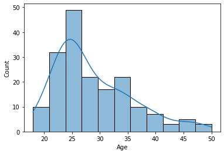

```python
sns.histplot(df.Age, kde=True);
```

### Observations

1. The distribution of Age is positive skewed
2. Majority of customers fall into the age group 24-27
3. Median age is 26 and the mean age is 29
4. Which most of the customers are of age group 24-27, we have observations where there are customers belonging to age group 45-50 as well

## Observations on Education

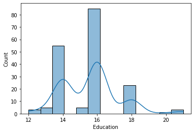

```python
sns.histplot(df.Education, kde = True)
```

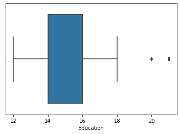

```python
sns.boxplot(df.Education,orient = "h");
```

## Observations

1. The distribution is negative skewed.
2. Most of the customers have 14 - 16 years of education. Though there are some who have more than 20 years.

## Observations on Usage

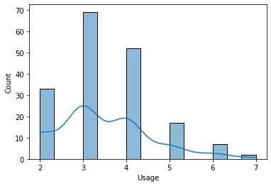

```python
#histogram_boxplot(df.Usage)
sns.histplot(df.Usage, kde = True)
```

## Observations

1. Most of the customers wants to use the threadmill thrice a weak.
2. The distribution of the Usage is positively skewed.
3. The mean is 3.5 times/weak and median is 3 times/weak
4. There are very less customers who want to use the threadmill everyday.

## Observations on Income

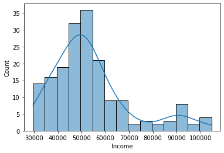

```python
sns.histplot(df.Income, kde=True);
```

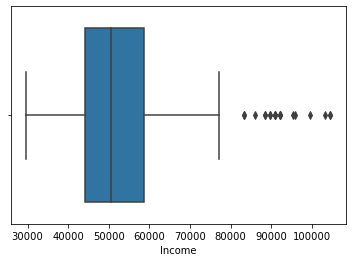

```python
sns.boxplot(df.Income,orient = "h");
```

### Observation

1. The distribution is highly positive skewed
2. Most of the customers income fall around (~50000)
3. There are many outliers in this variable.
4. While most of the customers Income are at lower end, we have observations where miles went as high as (~100000)

## Observations on Miles

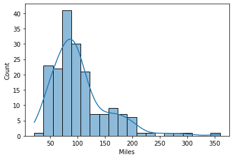

```python
sns.histplot(df.Miles, kde=True);
```

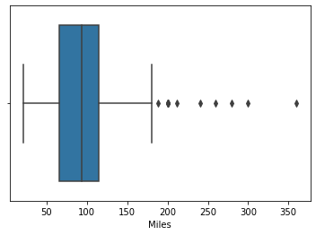

```python
sns.boxplot(df.Miles,orient = "h");
```

### Observations

1. The distribution of miles is highly right skewed.
2. Most of the customers are expected to run 75 miles.
3. Mean and median are almost close to ~100
4. There are outliers in this variable.
5. While most of the miles are at lower end, we have observations where miles went as high as (~350)

# Lets explore the categorical Variables now

## Observation on Product

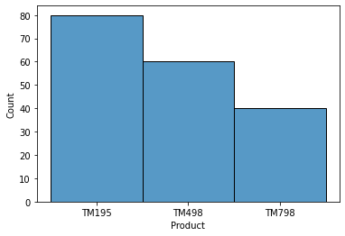

```python
sns.histplot(df.Product);
```

### Observations

1. Most of the customers use the Product TM195(44.4%), 33.3% customers use TM498 and 22.2% customers use TM798

## Observation on Marital Status

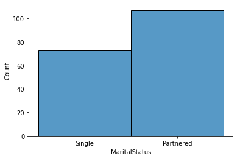

```python
sns.histplot(df.MaritalStatus);
```

### Observations:

1. 59.4% of the customers are Partnered.

## Observation on Gender

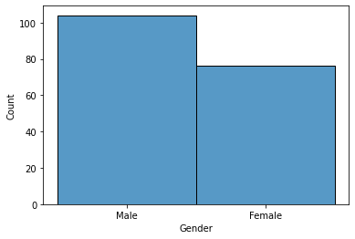

```python
sns.histplot(df.Gender);
```

### Observations

1. Number of Male customers are more than Female customers.

# Bivariate Analysis

## Plotting Bivariate Analysis to understand the interaction with each other.

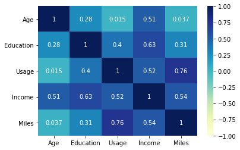

```python
sns.heatmap(df.corr(),cmap="YlGnBu",vmin=-1,vmax=1, annot=True)
```

### Observations

1. Miles show high correlation with Usage
2. There doesnot seem strong relation between age and education.
3. It is important to note that correlation does not imply causation.
4. All are positively correlated.

# Bivariate Scatter Plots

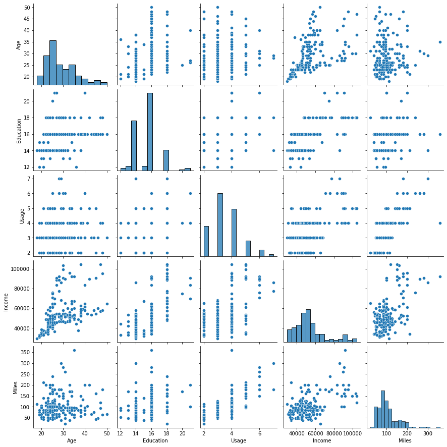

```python
#sns.pairplot(df[num_var], corner=True)
#plt.show()
sns.pairplot(df);
```

## Relationship between Usage and Miles

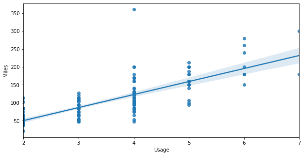

```python
fig = plt.figure(figsize= (10,5))
ax = sns.regplot(x ='Usage', y = df['Miles'], data = df)
```

### Observation

Customer usage and miles expected to cover are linearly proportional.

## Relationship between Education and Income

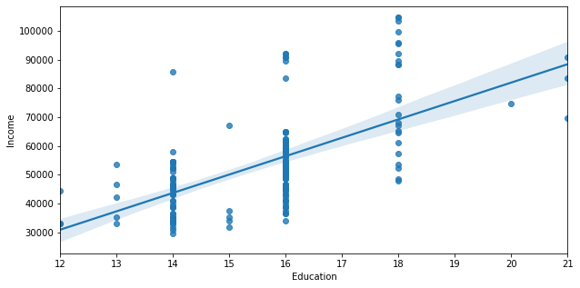

```python
fig = plt.figure(figsize= (10,5))
ax = sns.regplot(x ='Education', y = df['Income'], data = df)
```

### Observation

1. Customers with more years of Education are expected to earn more.

## Relationship between Income and Usage

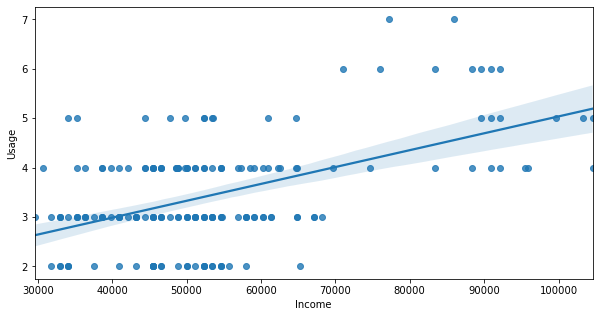

```python
fig = plt.figure(figsize= (10,5))
ax = sns.regplot(x ='Income', y = df['Usage'], data = df)
```

### Observation

1. Higher the Income, threadmill usage is more.
2. Most of the Customers fall in the category whose income is less than 60000 and their usage is between 2-4times/wk

## Relationship between Income and Miles

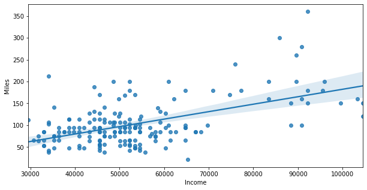

```python
fig = plt.figure(figsize= (10,5))
ax = sns.regplot(x ='Income', y = df['Miles'], data = df)
```

### Observation:

1. The lesser the income, number of miles expected to run is less.

## Frequency table for Age

```python
dfcrosstab = pd.crosstab(index=df["Age"], columns="count")## Check frequency of transactions by age.
print(dfcrosstab)
```

```
col_0  count
Age
18         1
19         4
20         5
21         7
22         7
23        18
24        12
25        25
26        12
27         7
28         9
29         6
30         7
```

[output cut: 19 more lines]

### Observation

1. There are many customers whose age falls in the range 23-26

```python
pd.crosstab(df.Product,df.Gender)## Check # Females and Males across each product.
```

| Gender Product | Female | Male |
| --- | --- | --- |
| TM195 | 40 | 40 |
| TM498 | 29 | 31 |
| TM798 | 7 | 33 |

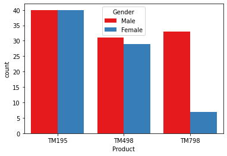

```python
sns.countplot(x="Product", hue="Gender", data=df, palette='Set1',saturation=50 );
```

### Observation:

1. Customers who use Product TM798 are mostly men.

## Check product count by MaritalStatus

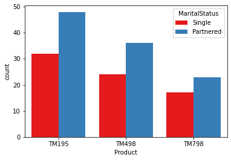

```python
sns.countplot(x="Product", hue="MaritalStatus", data=df, palette='Set1',saturation=50 );
```

### Observation:

1. There are more patnered customers who buy the equipment than single people.

## Check product count by fitness

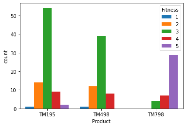

```python
sns.countplot(x="Product", hue="Fitness", data=df, palette='tab10',saturation=50 );
plt.show()
```

### Observation

1.Customers with fitness level 5 mostly buy TM798. 2.Customers with fitness level 3 mostly buy TM195.

## Check product count by Education

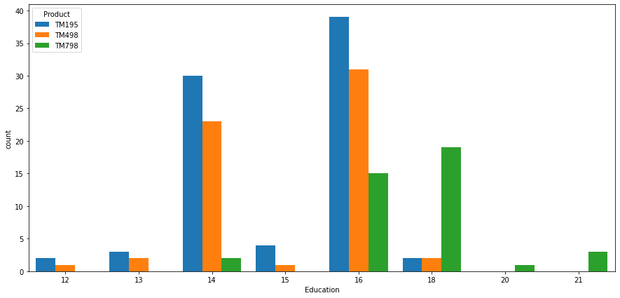

```python
figure = plt.figure(figsize=(15,7))
sns.countplot(x="Education", hue="Product", data=df, palette='tab10',saturation=50 );
plt.show()
```

### Observation

1. Customers with more educational years use TM798
2. Customers with less educational years use TM195
3. Customers with educational years between (14-16 years) tend to use TM498 and TM 195

## Check correlation between fitness and miles

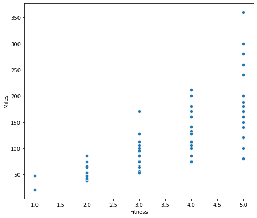

```python
figure = plt.figure(figsize=(8,7))
sns.scatterplot(x="Fitness", y="Miles", data=df, palette='tab10' )
plt.show()
```

### Observation

1. Customers who rate themselves high are expected to run more miles.

## Correlation between Fitness, Miles and Gender

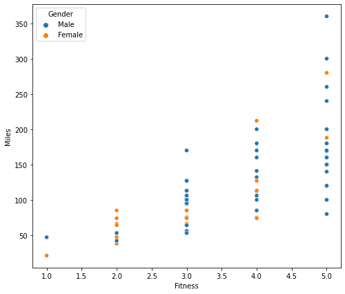

```python
figure = plt.figure(figsize=(8,7))
sns.scatterplot(x="Fitness", y="Miles", data=df, hue='Gender', palette='tab10' )
plt.show()
```

## Correlation between Fitness, Miles and Product

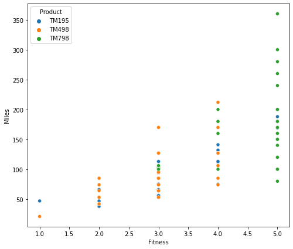

```python
figure = plt.figure(figsize=(8,7))
sns.scatterplot(x="Fitness", y="Miles", data=df, hue='Product', palette='tab10' )
plt.show()
```

### Observation

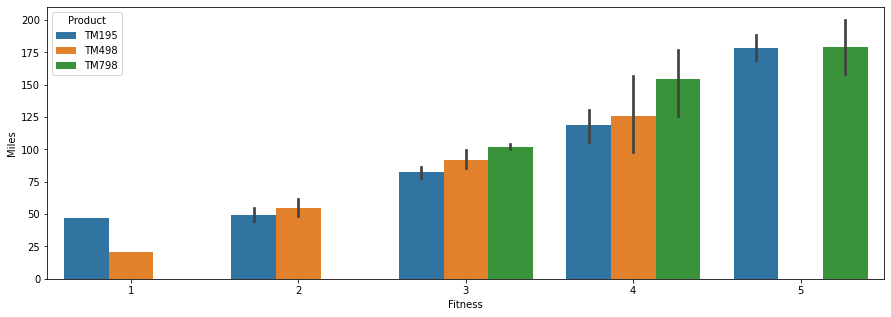

```python
fig = plt.figure(figsize= (15,5))
ax = sns.barplot(x ='Fitness', y = 'Miles', data = df, hue = 'Product')
```

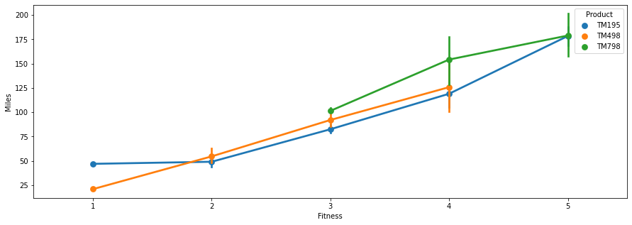

```python
fig = plt.figure(figsize= (15,5))
ax = sns.pointplot(x ='Fitness', y = 'Miles', data = df, hue = 'Product')
```

## Check relation between Gender, Income and Marital Status

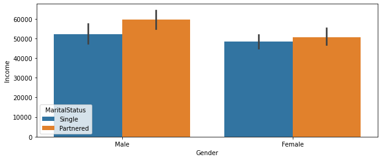

```python
figure = plt.figure(figsize=(10,4))
sns.barplot(data=df, x='Gender', y ='Income', hue='MaritalStatus')
plt.show()
```

## Check relation between fitness, miles and gender.

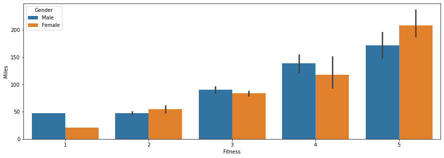

```python
fig = plt.figure(figsize= (15,5))
ax = sns.barplot(x ='Fitness', y = 'Miles', data = df, hue = 'Gender')
```

### Observation

1. Female customers who rate themselves high are expected to run more miles.